# Statistica_Descrittiva_Project

# PROBABILITY CALCULATION

```r
library(ggplot2)
```

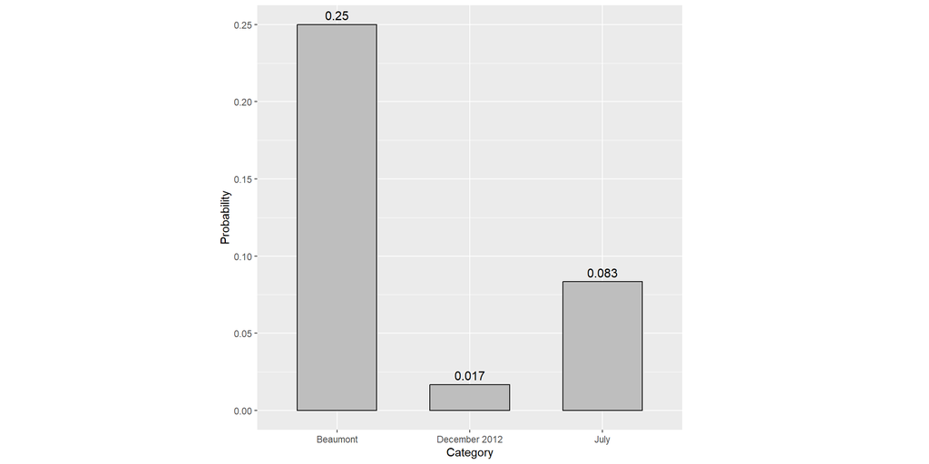

```r
total_obs <- nrow(realestate_texas)
num_beaumont <- sum(city == "Beaumont")
prob_beaumont <- num_beaumont / total_obs

num_july <- sum(month == "7")
prob_july <- num_july / total_obs

year_month <- paste(year, month, sep = "-")
num_dec_2012 <- sum(year_month == "2012-12")
prob_dec_2012 <- num_dec_2012 / total_obs

prob_data <- data.frame(
  Category = c("Beaumont", "July", "December 2012"),
  Probability = c(prob_beaumont, prob_july, prob_dec_2012)
)

combined_plot <- ggplot(prob_data, aes(x = Category, y = Probability)) +
  geom_bar(stat = "identity", col = "black", fill = "gray", width = 0.6) +
  geom_text(aes(y = Probability, label = round(Probability, 3)),
            color = "black", vjust = -0.5, size = 4) +
  labs(x = "Category", y = "Probability") +
  theme(aspect.ratio = 1, plot.margin = margin(5, 30, 5, 5))

combined_plot
```

The probability that, taken a random row in this dataset, it carries the city “Beaumont” is 0.25, or 25% of the cases; the probability that, taken a random row in this dataset, it carries the month and year “December 2012” is about 0.017, or about 1.7% of the cases and the probability that, taken a random row in this dataset, it carries the month “July” is about 0.083, or about 8.3% of the cases.

# CREATION OF NEW VARIABLES

```r
realestate_texas$mean_price <- volume/sales * 1000000
```

“mean_price” represents the average sales price per unit. It was calculated as the ratio of the total sales volume (volume) to the total number of sales (sales), multiplied by 1,000,000 to express the result in dollars (volume is expressed in millions of dollars). Basically, this value gives you the average sales price of a property for each completed transaction.

```r
realestate_texas$sales_efficiency <- round(realestate_texas$sales / realestate_texas$listings, 3)
View(realestate_texas)
```

“sales_efficiency” measures the efficiency with which properties are sold. It is calculated as the ratio of the total number of sales (sales) to the total number of active listings (listings). This variable indicates how many sales are made per active listing. A higher value suggests that properties are sold faster than the number of listings, while a low value indicates that there are many listings for sale without corresponding equally high sales. If sales_efficiency values are high, it means that sales listings are more effective in bringing about a transaction. This could be the case during periods or in cities with high demand for real estate, where listings find buyers quickly. If sales_efficiency values are low, this could indicate that properties are remaining unsold for longer periods, which could reflect low demand, prices that are too high, or other issues related to properties for sale. Finally, we see the new variables in the dataset.

# CONDITIONAL ANALYSIS

```r
library(dplyr)
library(ggplot2)
library(tidyr)
```

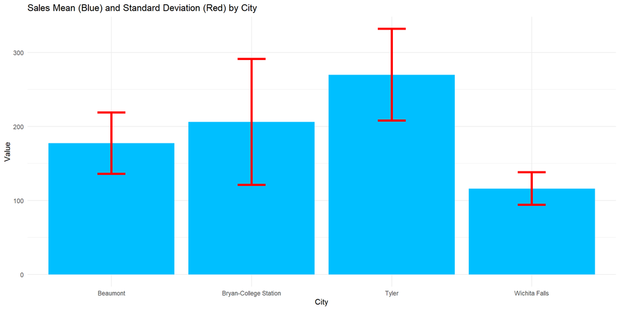

```r
summary_data_city_sales <- realestate_texas %>%
  group_by(city) %>%
  summarise(mean = mean(sales),
            st_dev = sd(sales))

summary_data_city_sales_plot <- ggplot(summary_data_city_sales) +
  geom_bar(aes(x = city, y = mean, fill = "Mean"),
           stat = "identity", position = "dodge") +
  geom_errorbar(aes(x = city, ymin = mean - st_dev, ymax = mean + st_dev, color = "Standard Deviation"), width = 0.2, linewidth = 1.5) +
  scale_fill_manual(values = c("Mean" = "#00BFFF")) +
  scale_color_manual(values = c("Standard Deviation" = "red1")) +
  labs(title = "Sales Mean (Blue) and Standard Deviation (Red) by City",
       x = "City",
       y = "Value") +
  theme_minimal() +
  theme(legend.position = "none")

summary_data_city_sales_plot
```

“Sales” shows a higher mean in “Tyler” and a higher variability in ”Brian-College Station”.

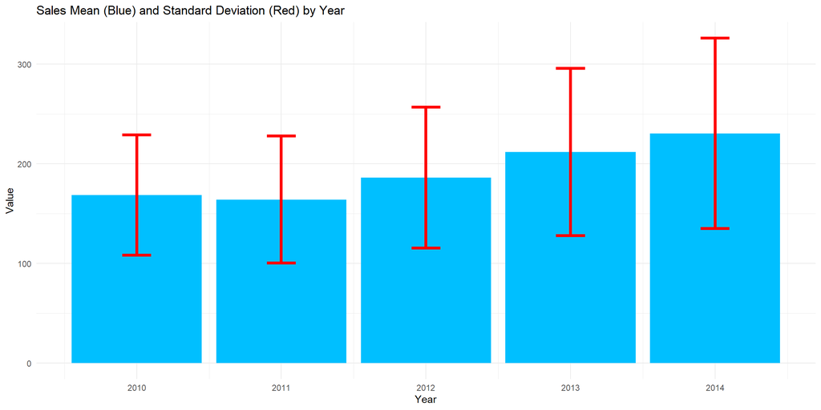

```r
summary_data_year_sales <- realestate_texas %>%
  group_by(year) %>%
  summarise(mean = mean(sales),
            st_dev = sd(sales))

summary_data_year_sales_plot <- ggplot(summary_data_year_sales) +
  geom_bar(aes(x = year, y = mean, fill = "Mean"),
           stat = "identity", position = "dodge") +
  geom_errorbar(aes(x = year, ymin = mean - st_dev, ymax = mean + st_dev, color = "Standard Deviation"), width = 0.2, linewidth = 1.5) +
  scale_fill_manual(values = c("Mean" = "#00BFFF")) +
  scale_color_manual(values = c("Standard Deviation" = "red1")) +
  labs(title = "Sales Mean (Blue) and Standard Deviation (Red) by Year",
       x = "Year",
       y = "Value") +
  theme_minimal() +
  theme(legend.position = "none")

summary_data_year_sales_plot
```

“Sales” shows a higher mean and a higher variability in ”2014”.

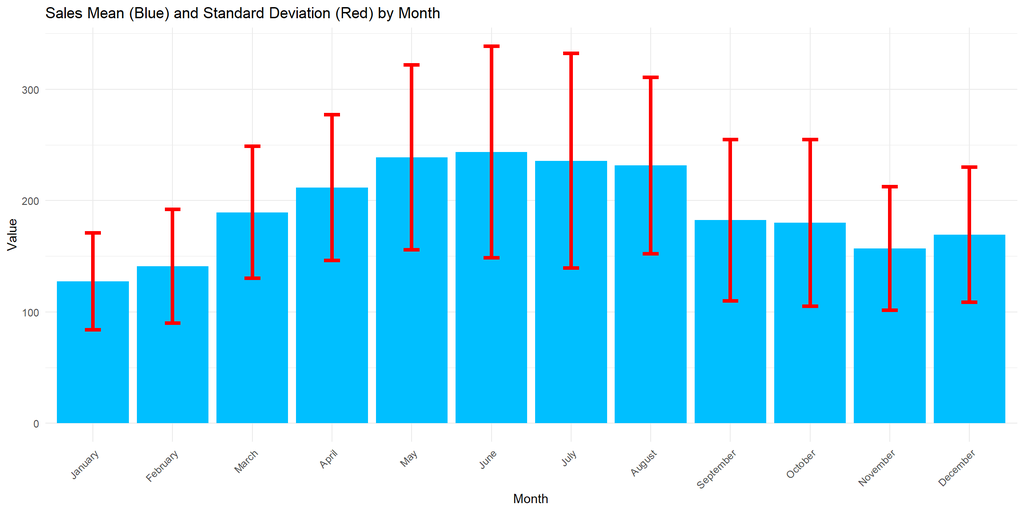

```r
summary_data_month_sales <- realestate_texas %>%
  group_by(month) %>%
  summarise(mean = mean(sales),
            st_dev = sd(sales)) %>%
  mutate(month = factor(month, levels = 1:12, labels = month.name))

summary_data_month_sales_plot <- ggplot(summary_data_month_sales) +
  geom_bar(aes(x = month, y = mean, fill = "Mean"),
           stat = "identity", position = "dodge") +
  geom_errorbar(aes(x = month, ymin = mean - st_dev, ymax = mean + st_dev, color = "Standard Deviation"), width = 0.2, linewidth = 1.5) +
  scale_fill_manual(values = c("Mean" = "#00BFFF")) +
  scale_color_manual(values = c("Standard Deviation" = "red1")) +
  labs(title = "Sales Mean (Blue) and Standard Deviation (Red) by Month",
       x = "Month",
       y = "Value") +
  theme_minimal() +
  theme(legend.position = "none", axis.text.x = element_text(angle = 45, hjust = 1))

summary_data_month_sales_plot
```

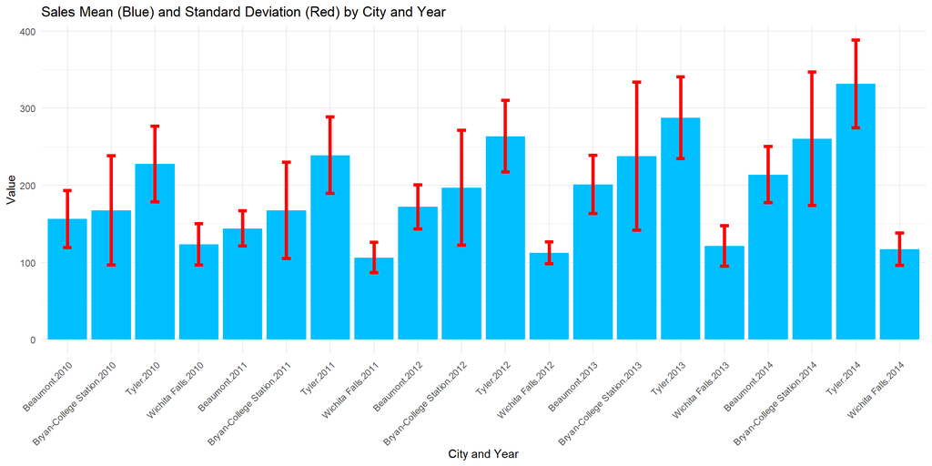

```r
summary_data_city_year_sales <- realestate_texas %>%
  group_by(city, year) %>%
  summarise(mean = mean(sales),
            st_dev = sd(sales),
            .groups = "keep")

summary_data_city_year_sales_plot <- ggplot(summary_data_city_year_sales) +
  geom_bar(aes(x = interaction(city, year), y = mean, fill = "Mean"),
           stat = "identity", position = "dodge") +
  geom_errorbar(aes(x = interaction(city, year),
                    ymin = mean - st_dev,
                    ymax = mean + st_dev,
                    color = "Standard Deviation"),
                width = 0.2, linewidth = 1.5) +
  scale_fill_manual(values = c("Mean" = "#00BFFF")) +
  scale_color_manual(values = c("Standard Deviation" = "red1")) +
  labs(title = "Sales Mean (Blue) and Standard Deviation (Red) by City and Year",
       x = "City and Year",
       y = "Value") +
  theme_minimal() +
  theme(legend.position = "none", axis.text.x = element_text(angle = 45, hjust = 1))

summary_data_city_year_sales_plot
```

“Sales” shows a higher mean in “Tyler 2014” and a higher variability in ”Brian-College Station 2013”.

# GGPLOT2 VISUALIZATIONS

```r
library(ggplot2)
library(lubridate)
library(dplyr)
```

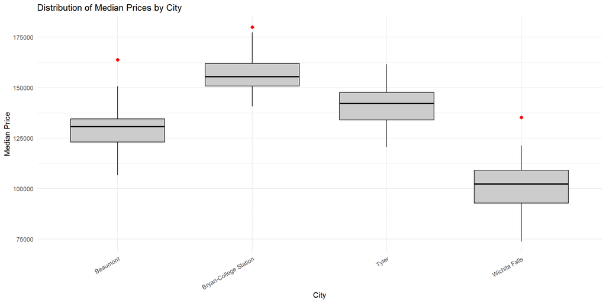

```r
# Median Prices by City box-plot
median_prices_boxplot <- ggplot(data = realestate_texas) +
  geom_boxplot(aes(x = city, y = median_price),
               fill = "gray80",
               color = "black",
               outlier.colour = "red",
               outlier.size = 2,
               width = 0.7) +
  labs(title = "Distribution of Median Prices by City",
       x = "City",
       y = "Median Price") +
  theme_minimal() +
  theme(axis.text.x = element_text(angle = 30, hjust = 1),
        legend.position = "none")

median_prices_boxplot
```

```r
Sys.setlocale("LC_TIME", "en_US.UTF-8")
```

```
## [1] "en_US.UTF-8"
```

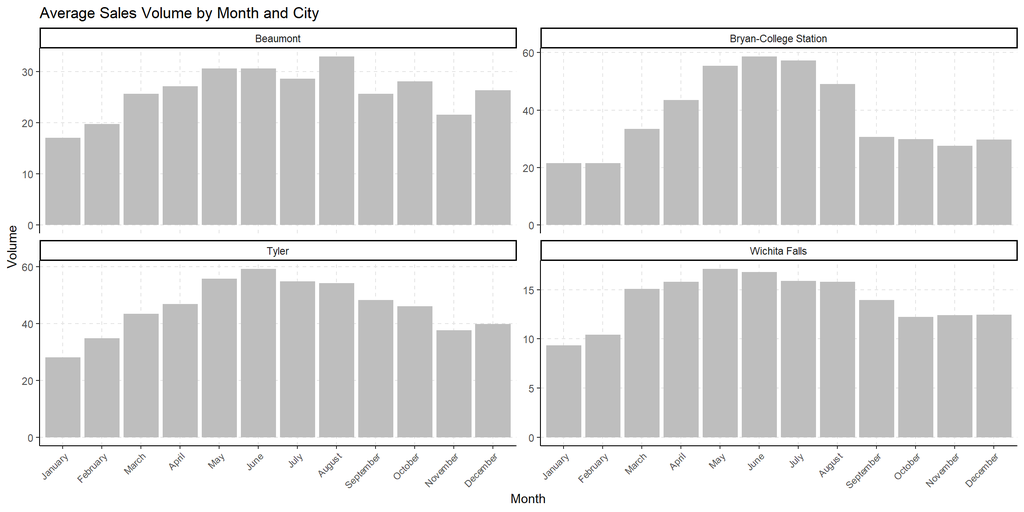

```r
# Average Sales Volume / Number of Sales by Month and City dodged barplots
dodged_barplot_1 <- function(variable, y_label, title) {
  monthly_data <- realestate_texas %>%
    group_by(city, month) %>%
    summarise(mean_value = mean(!!sym(variable), na.rm = TRUE), .groups = "drop") %>%
    mutate(month = factor(month, levels = 1:12, labels = month.name))

  ggplot(data = monthly_data) +
    geom_bar(aes(x = month, y = mean_value), stat = "identity", position = "dodge", fill = "gray") +
    facet_wrap(~ city, scales = "free_y") +
    labs(title = title,
         x = "Month", y = y_label) +
    scale_x_discrete(labels = month.name) +
    theme_classic() +
    theme(
      axis.text.x = element_text(angle = 45, hjust = 1, size = 8),
      panel.grid.major = element_line(color = "gray90", linetype = "dashed"),
      panel.grid.minor = element_blank(),
      legend.position = "none"
    )
}

dodged_barplot_volume_1 <- dodged_barplot_1("volume", "Volume", "Average Sales Volume by Month and City")
dodged_barplot_sales_1 <- dodged_barplot_1("sales", "Sales", "Average Number of Sales by Month and City")

dodged_barplot_volume_1
```

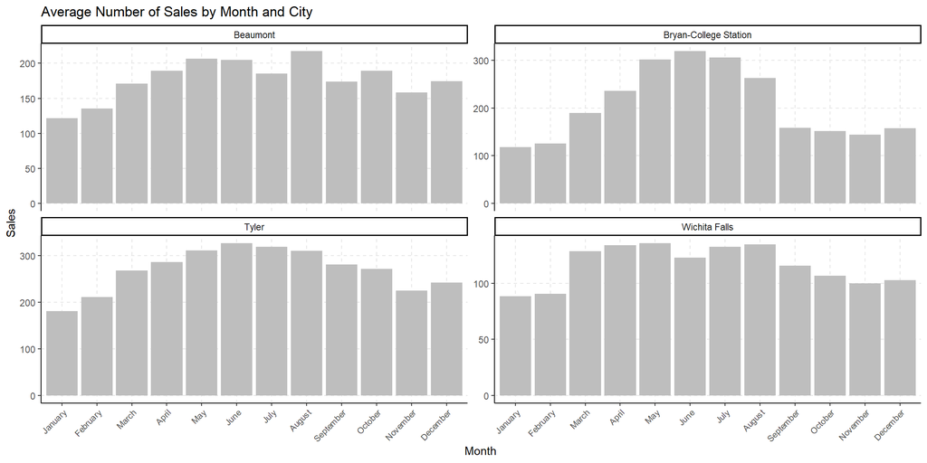

```r
dodged_barplot_sales_1
```

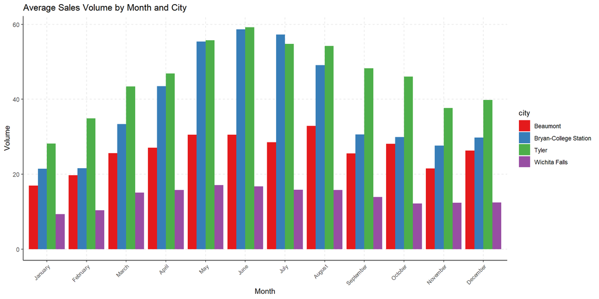

```r
dodged_barplot_2 <- function(variable, y_label, title) {
  monthly_data <- realestate_texas %>%
    group_by(city, month) %>%
    summarise(mean_value = mean(!!sym(variable), na.rm = TRUE), .groups = "drop") %>%
    mutate(month = factor(month, levels = 1:12, labels = month.name))

 ggplot(data = monthly_data) +
    geom_bar(aes(x = month, y = mean_value, fill = city), stat = "identity", position = "dodge") +
    labs(title = title,
         x = "Month", y = y_label) +
    scale_x_discrete(labels = month.name) +
    scale_fill_brewer(palette = "Set1") +
    theme_classic() +
    theme(
      axis.text.x = element_text(angle = 45, hjust = 1, size = 8),
      panel.grid.major = element_line(color = "gray90", linetype = "dashed"),
      panel.grid.minor = element_blank(),
      legend.position = "right"
    )
}

dodged_barplot_volume_2 <- dodged_barplot_2("volume", "Volume", "Average Sales Volume by Month and City")
dodged_barplot_sales_2 <- dodged_barplot_2("sales", "Sales", "Average Number of Sales by Month and City")

dodged_barplot_volume_2
```

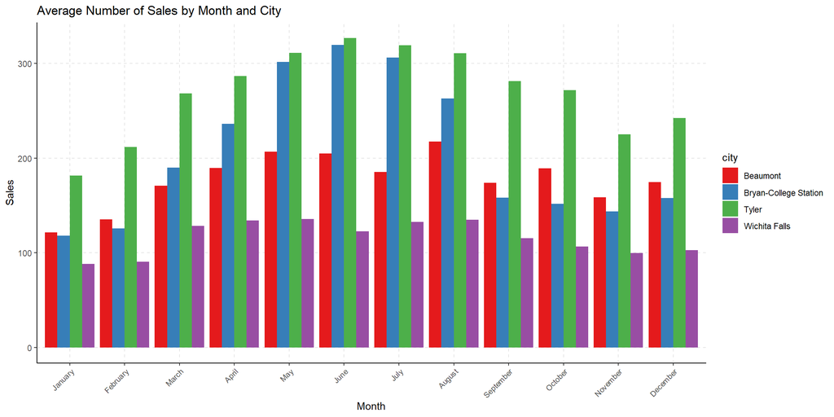

```r
dodged_barplot_sales_2
```

Unlike before, here we can compare the different distributions of sales volumes/number of sales among different cities and how they evolve over time (every months was calculated like the previous dodged barplots): Tyler and Brian-College Station turn out to have the highest and most increasing sales volumes/number of sales over time, with the same concentration of higher sales volumes/number of sales during the spring/summer periods.

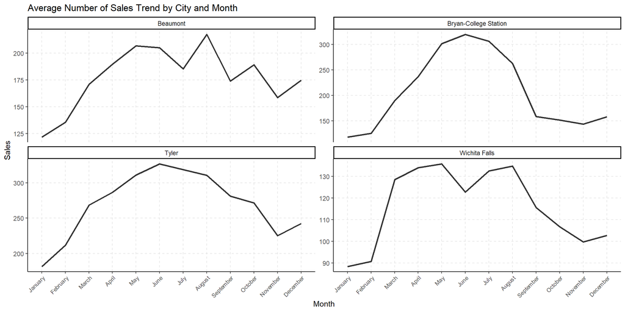

```r
# Average Sales Volume / Number of Sales by Month and City time series
time_series_plot_1 <- function(variable, y_label, title) {
  monthly_data <- realestate_texas %>%
    group_by(city, month) %>%
    summarise(mean_value = mean(!!sym(variable), na.rm = TRUE), .groups = "drop") %>%
    mutate(month = factor(month, levels = 1:12, labels = month.name))

  ggplot(data = monthly_data) +
    geom_line(aes(x = month, y = mean_value, group = city),
              linewidth = 1, alpha = 0.8, linetype = "solid", color = "black") +
    facet_wrap(~city, scales = "free_y") +
    labs(
      title = title,
      x = "Month", y = y_label,
      color = "City"
    ) +
    scale_x_discrete(labels = month.name) +
    theme_classic() +
    theme(
      axis.text.x = element_text(angle = 45, hjust = 1, size = 8),
      panel.grid.major = element_line(color = "gray90", linetype = "dashed"),
      panel.grid.minor = element_blank(),
      legend.position = "none"
    )
}

time_series_plot_sales_1 <- time_series_plot_1("sales", "Sales", "Average Number of Sales Trend by City and Month")
time_series_plot_volume_1 <- time_series_plot_1("volume", "Volume", "Average Sales Volume Trend by City and Month")

time_series_plot_sales_1
```

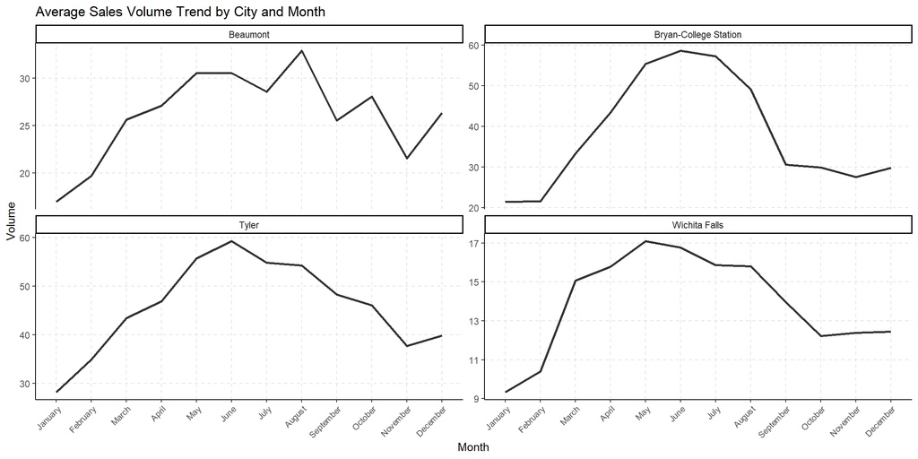

```r
time_series_plot_volume_1
```

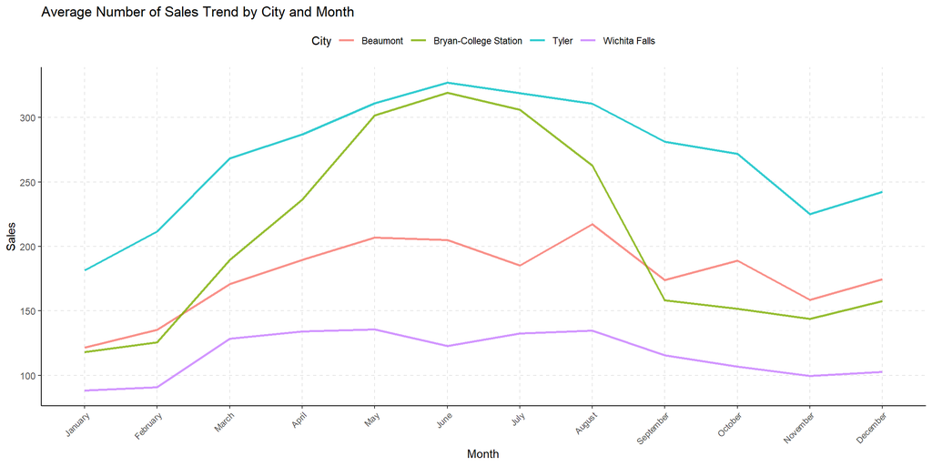

```r
time_series_plot_2 <- function(variable, y_label, title) {
  monthly_data <- realestate_texas %>%
    group_by(city, month) %>%
    summarise(mean_value = mean(!!sym(variable), na.rm = TRUE), .groups = "drop") %>%
    mutate(month = factor(month, levels = 1:12, labels = month.name))

  ggplot(data = monthly_data) +
    geom_line(aes(x = month, y = mean_value, color = city, group = city),
              linewidth = 1, alpha = 0.8, linetype = "solid") +
    labs(
      title = title,
      x = "Month", y = y_label,
      color = "City"
    ) +
    scale_x_discrete(labels = month.name) +
    theme_classic() +
    theme(
      axis.text.x = element_text(angle = 45, hjust = 1, size = 8),
      panel.grid.major = element_line(color = "gray90", linetype = "dashed"),
      panel.grid.minor = element_blank(),
      legend.position = "top"
    )
}

time_series_plot_sales_2 <- time_series_plot_2("sales", "Sales", "Average Number of Sales Trend by City and Month")
time_series_plot_volume_2 <- time_series_plot_2("volume", "Volume", "Average Sales Volume Trend by City and Month")

time_series_plot_sales_2
```

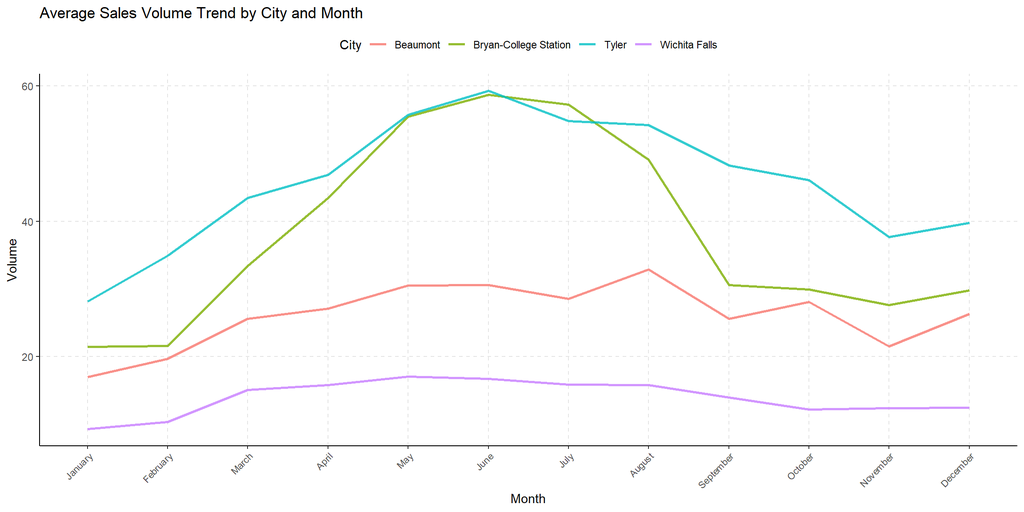

```r
time_series_plot_volume_2
```

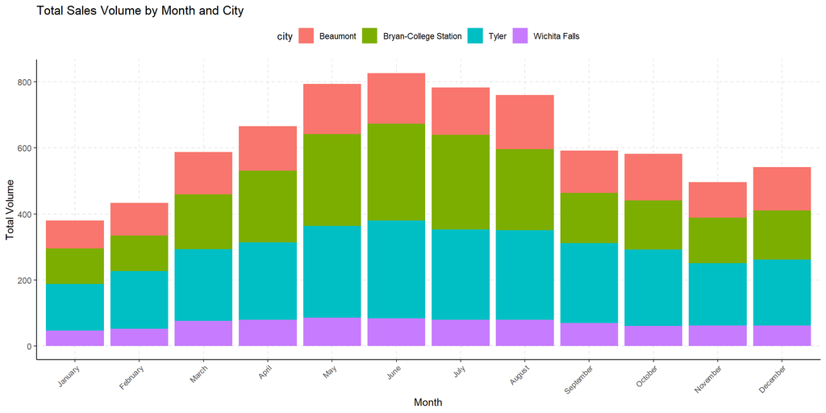

```r
# Total Sales Volume / Number of Sales by Month and City stacked barplots
stacked_barplot_1 <- function(variable, y_label, title) {

  monthly_data <- realestate_texas %>%
    group_by(city, month) %>%
    summarise(sum_value = sum(!!sym(variable), na.rm = TRUE), .groups = "drop") %>%
    mutate(month = factor(month, levels = 1:12, labels = month.name))

  ggplot(data = monthly_data) +
    geom_bar(aes(x = month, y = sum_value, fill = city), stat = "identity", position = "stack") +
    labs(title = title,
         x = "Month", y = y_label) +
    scale_x_discrete(labels = month.name) +
    theme_classic() +
    theme(
      axis.text.x = element_text(angle = 45, hjust = 1, size = 8),
      panel.grid.major = element_line(color = "gray90", linetype = "dashed"),
      panel.grid.minor = element_blank(),
      legend.position = "top"
    )
}

stacked_barplot_volume_1 <- stacked_barplot_1("volume", "Total Volume", "Total Sales Volume by Month and City")
stacked_barplot_sales_1 <- stacked_barplot_1("sales", "Total Sales", "Total Number of Sales by Month and City")

stacked_barplot_volume_1
```

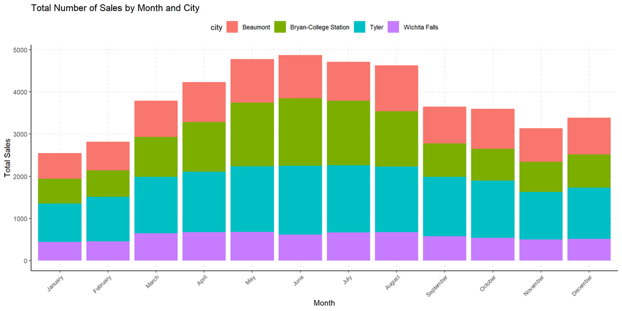

```r
stacked_barplot_sales_1
```

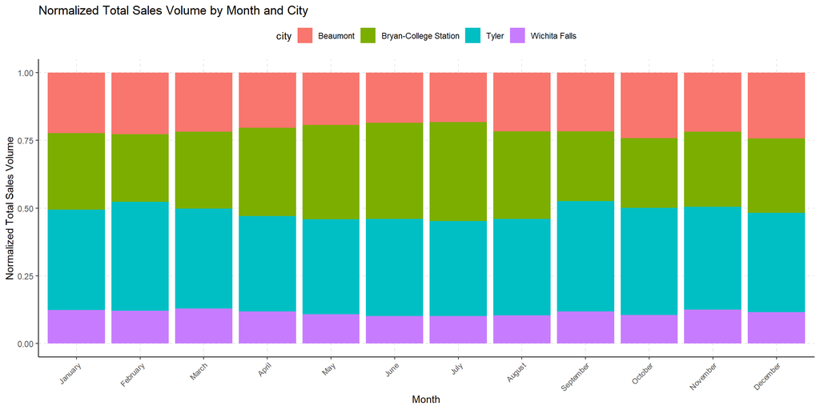

```r
stacked_barplot_2 <- function(variable, y_label, title) {

  monthly_data <- realestate_texas %>%
    group_by(city, month) %>%
    summarise(sum_value = sum(!!sym(variable), na.rm = TRUE), .groups = "drop") %>%
    mutate(month = factor(month, levels = 1:12, labels = month.name))

  ggplot(data = monthly_data) +
    geom_bar(aes(x = month, y = sum_value, fill = city), stat = "identity", position = "fill") +
    labs(title = title,
         x = "Month", y = y_label) +
    scale_x_discrete(labels = month.name) +
    theme_classic() +
    theme(
      axis.text.x = element_text(angle = 45, hjust = 1, size = 8),
      panel.grid.major = element_line(color = "gray90", linetype = "dashed"),
      panel.grid.minor = element_blank(),
      legend.position = "top"
    )
}

stacked_barplot_volume_2 <- stacked_barplot_2("volume", "Normalized Total Sales Volume", "Normalized Total Sales Volume by Month and City")
stacked_barplot_sales_2 <- stacked_barplot_2("sales", "Normalized Total Sales", "Normalized Total Number of Sales by Month and City")

stacked_barplot_volume_2
```

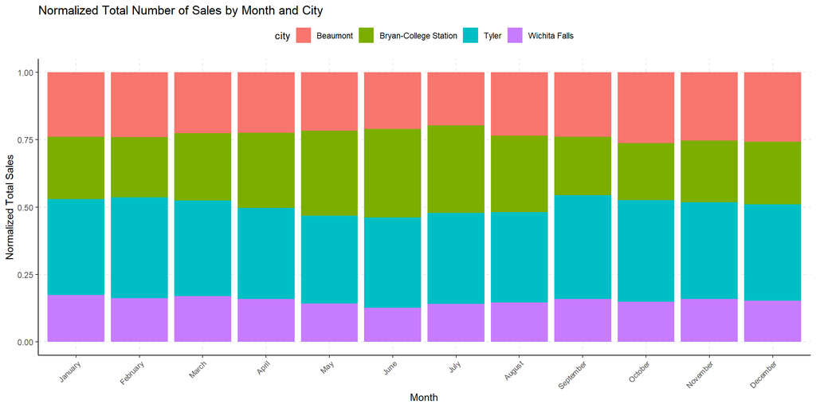

```r
stacked_barplot_sales_2
```

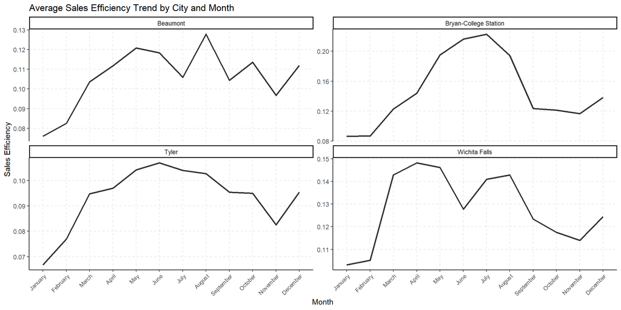

```r
# Average Sales Efficiency by Month and City time series
time_series_plot_sales_efficiency_1 <- time_series_plot_1("sales_efficiency", "Sales Efficiency", "Average Sales Efficiency Trend by City and Month")

time_series_plot_sales_efficiency_1
```

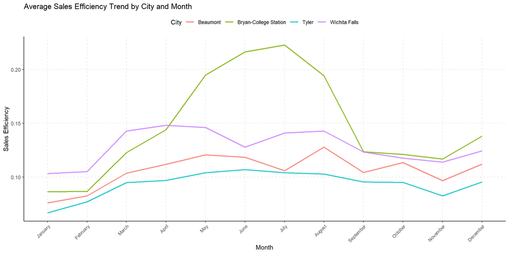

```r
time_series_plot_sales_efficiency_2 <- time_series_plot_2("sales_efficiency", "Sales Efficiency", "Average Sales Efficiency Trend by City and Month")

time_series_plot_sales_efficiency_2
```

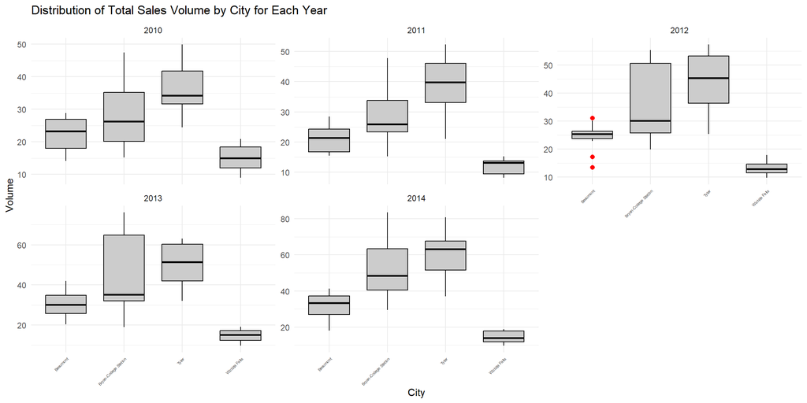

```r
volume_boxplots <- ggplot(data = realestate_texas) +
  geom_boxplot(aes(x = city, y = volume),
               fill = "gray80",
               color = "black",
               outlier.colour = "red",
               outlier.size = 2,
               width = 0.7) +
  labs(title = "Distribution of Total Sales Volume by City for Each Year",
       x = "City",
       y = "Volume") +
  theme_minimal() +
  theme(
    axis.text.x = element_text(angle = 45, hjust = 1, size = 4),
    legend.position = "none"
  ) +
  facet_wrap(~ year, scales = "free_y")

volume_boxplots
```

Several box plots have been created, as many as the years, and for each year, a comparison is made between the medians, Q1, Q3, and ranges across different cities regarding sales volumes: it can be observed that, generally, for each year, Tyler and Brian-College Station show fairly similar distribution values. However, in 2012 and 2013, although Brian-College Station has a lower median than Tyler, it shows a Q3 that is slightly lower (2012) and slightly higher (2013) than that of Tyler. It is worth noting that Beaumont, in 2012, shows several outliers.

# CONCLUSIONS

Based on the charts seen above, Brian-College Station and Tyler have the highest value distributions, especially when talking about sales volume and sales numbers. In spite of this, for all cities we have a very high concentration of values during the spring/summer periods, and this trend is repeated in every year: real estate sales tend, as a rule, to go up during the good season periods, since many more visits at properties for sale by, for example, real estate agencies are also encouraged. Thus, from the insights extrapolated from the analyses done so far, in order to increase the effectiveness of real estate listings, one could increase the volume of listings published within the “hottest” periods (spring/summer) and trying to diversify the channels, including digital channels, where the listings themselves are published, in order to attract a greater volume of customers. These conclusions are particularly relevant for cities like Beaumont and Wichita Falls, which have significant room for improvement, especially in terms of sales volumes and sales numbers.